# Assignment 2

Athena Rodrigues

2025-04-03

# Question 1

```r
data <- read_csv("usmelec.csv")
```

```
## ──────────────────────────────────────────────────────── Delimiter: "," dbl
## (3): ...1, time, val
```

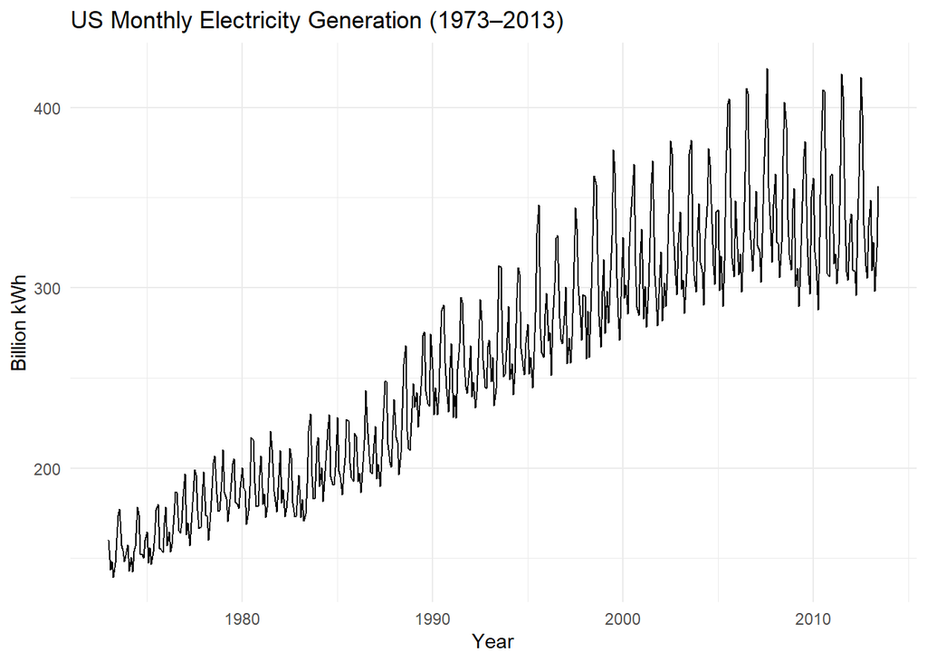

```r
data_ts <- ts(data$val, start = c(1973, 1), frequency = 12)
autoplot(data_ts) +
  ggtitle("US Monthly Electricity Generation (1973–2013)") +
  ylab("Billion kWh") + xlab("Year") + theme_minimal()
```

# Question 2

```r
decomp <- stl(data_ts, s.window = "periodic")

seasonal <- decomp$time.series[, "seasonal"]
head(seasonal)
```

```
##            Jan       Feb       Mar       Apr       May       Jun
## 1973  12.56265 -18.62459 -11.49811 -28.46503 -10.63306  12.62006
```

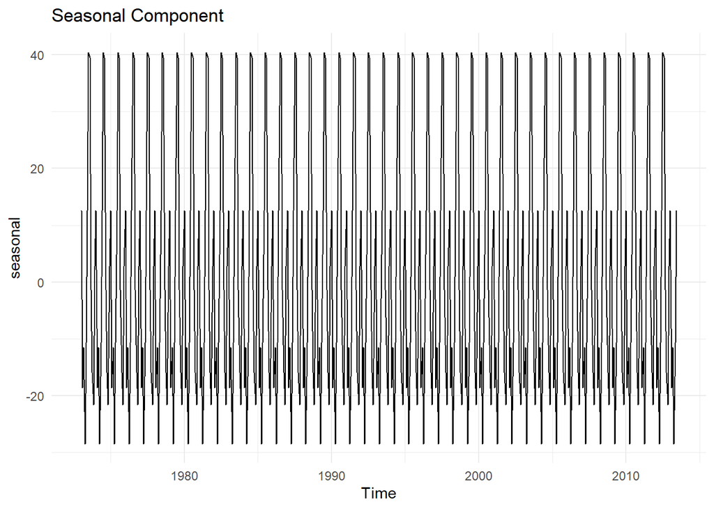

```r
autoplot(seasonal) + ggtitle("Seasonal Component") + theme_minimal()
```

```r
trend <- decomp$time.series[, "trend"]
head(trend)
```

```
##           Jan      Feb      Mar      Apr      May      Jun
## 1973 154.7780 154.7253 154.6726 154.7661 154.8596 155.0490
```

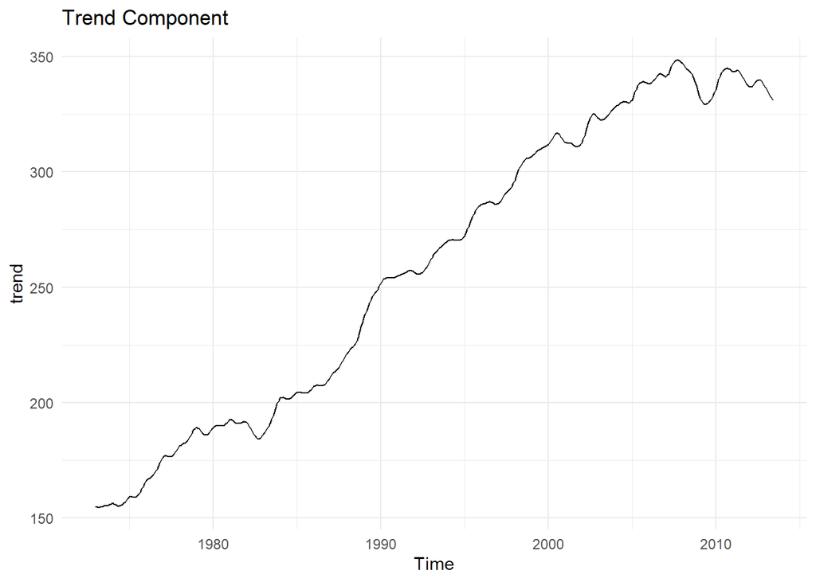

```r
autoplot(trend) + ggtitle("Trend Component") + theme_minimal()
```

```r
remainder <- decomp$time.series[, "remainder"]
head(remainder)
```

```
##            Jan       Feb       Mar       Apr       May       Jun
## 1973 -7.122618  7.438280  4.983467 13.287884  3.168423 -6.425058
```

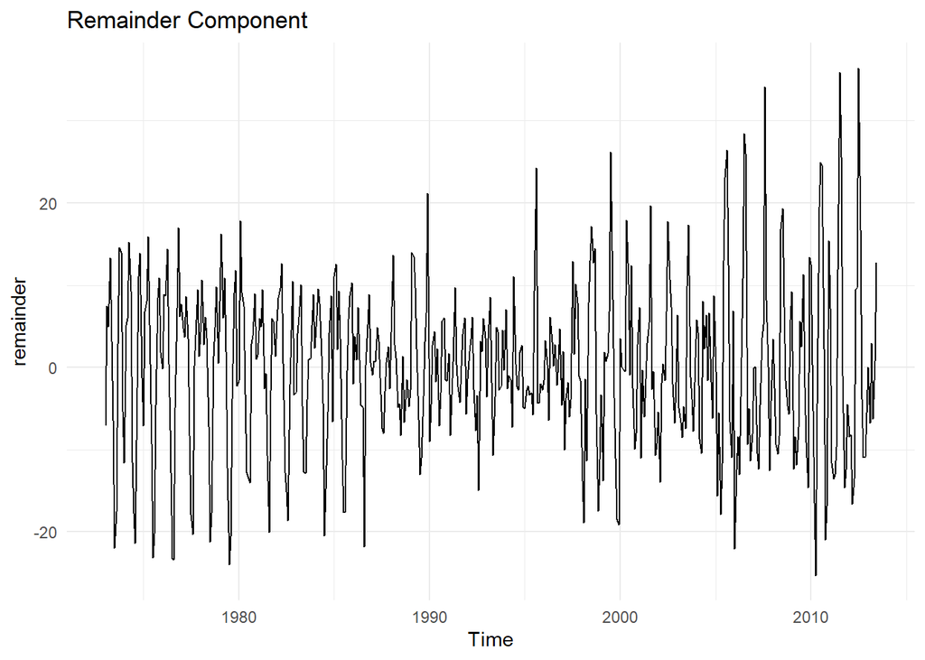

```r
autoplot(remainder) + ggtitle("Remainder Component") + theme_minimal()
```

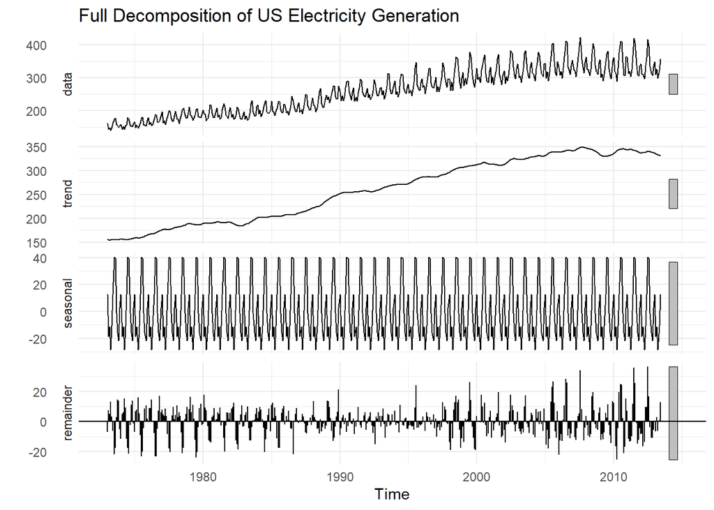

```r
autoplot(decomp) +
  ggtitle("Full Decomposition of US Electricity Generation") +
  theme_minimal()
```

# Question 3

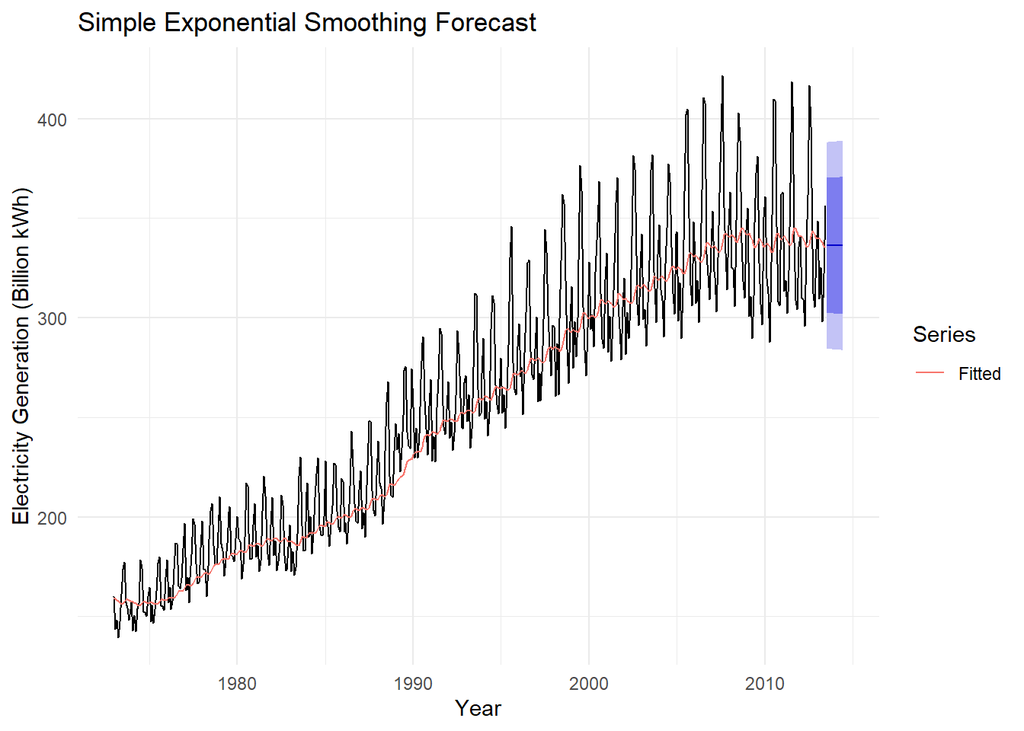

```r
smooth <- ses(data_ts, h=12, alpha = 0.05)
autoplot(smooth) +
  autolayer(fitted(smooth), series = "Fitted") +
  ggtitle("Simple Exponential Smoothing Forecast") +
  ylab("Electricity Generation (Billion kWh)") +
  xlab("Year") +
  guides(colour = guide_legend(title = "Series")) +
  theme_minimal()
```

# Question 4

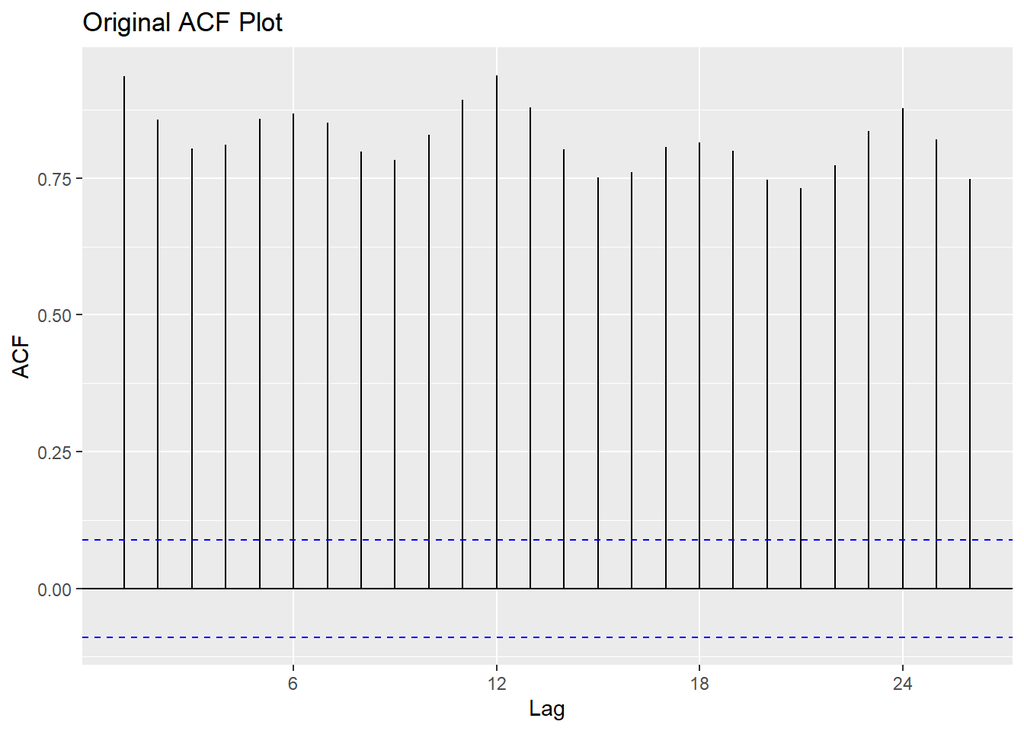

```r
#non-stationary
ggAcf(data_ts) +  ggtitle("Original ACF Plot")
```

Original ACF plot: There is high autocorrelation at multiple lags which can be seen in spikes at seasonal intervals, every 12 months. This shows a strong seasonality that is expected with monthly electricity generation data. If there were a quick drop in ACF to zero the data would be stationary. However, the slow decay in autocorrelation indicated non-stationarity.

Addressing ACF: To properly model this data differencing is needed to remove trends and stabilize data. This could be done through seasonal differencing (lag =12) that would prepare the data for an ARIMA or seasonal ARIMA model which could account for trend and seasonal autocorrelation.

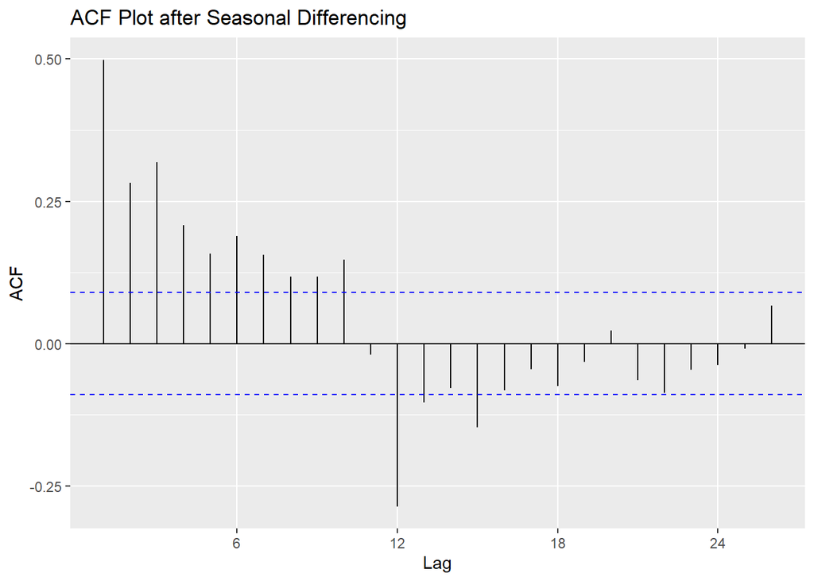

```r
#seasonal differencing
differencing <- diff(data_ts, lag = 12)
ggAcf(differencing) +
  ggtitle("ACF Plot after Seasonal Differencing")
```